# Multi-trait and multi-environment strategies for Genomic Selection (GS)

Marcio Resende, professor[^1]

Diego Jarquin, professor[^2]

Marco Antonio Peixoto, Post doc[^3]

## 1. Introduction to simulations pipeline

Simulations have been demonstrated as a powerful tool to improve animal and plant breeding programs. In addition, those tools may offer an alternative to address theoretical concepts in quantitative genetics and breeding.

Here, we will use `AlphaSimR` package (Gaynor et al. 2021). The package uses stochastic simulations for design and optimization of breeding programs. The package offers a fast, simple, and inexpensive way to test alternative breeding programs.

```r
rm(list=ls())

#install.packages("AlphaSimR")
require(AlphaSimR)
```

For a whole set of simulations, four simple steps must be included, as follows:

1. Simulate founder genomes/haplotypes.
2. Set global simulation parameters for a target trait.
3. Modeling the breeding program.
4. Examining results by looking into population individuals.

## 2. Multi-trait information over several cycles

Breeding programs are often targeting the improvement of several traits at a time. However, in a multi-trait framework, we may consider the correlations in-between the traits. Correlation may vary from -1 to 1, and the signal and the magnitude will impact the response with selection.

### Positive correlation

First, we will check a case where two traits were simulated, with a positive correlation between them. In addition, the selection will be made in only one trait and we will be able to measure the indirect response in the other trait.

```r
rm(list=ls())
require(AlphaSimR)
set.seed(53627)

#--- 1. Founder genome
founderGen = runMacs(nInd = 100,
                         nChr = 10,
                         segSites = 100,
                         species = "MAIZE")
SP = SimParam$new(founderGen)


#--- 2. Define the traits
means = c(100, 100)
vars = c(10, 20)
cors = matrix(data = c( 1.0, 0.3,
                       0.3,  1.0),
                byrow = TRUE, nrow = 2, ncol = 2)
h2s = c(0.5, 0.5)
SP$addTraitA(nQtlPerChr = 100,
             mean = means,
             var = vars,
             corA = cors)
```

Create the base population for later selection.

```r
# Base population
basePop = newPop(founderGen)

# Phenotype the population
basePop = setPheno(basePop, h2 = h2s)
```

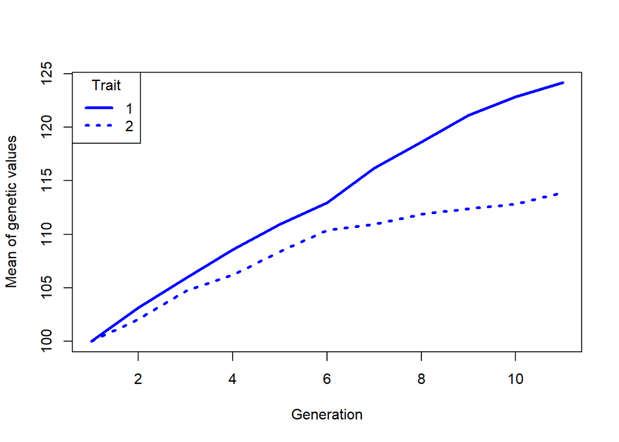

```r
# Store the results
nGenerations = 10 + 1 # +1 to store starting generation
meanG = vector("list", length = nGenerations)
varG = vector("list", length = nGenerations)

# Save the starting values
meanG[[1]] = meanG(basePop)
varG[[1]] = varG(basePop)

# First selection step
nSelected = 20
newPopSelected = selectInd(pop = basePop,
                           nInd = nSelected,
                           use = "pheno",
                           trait = 1)

# Selection over many generations
for (generation in 1:(nGenerations - 1)) {
  newPop = randCross(newPopSelected, nCrosses = nInd(basePop))
  newPop = setPheno(newPop, h2 = h2s)
  newPopSelected = selectInd(pop = newPop,
                             nInd = nSelected,
                             use = "pheno",
                             trait = 1)
  # Save summaries
  meanG[[1 + generation]] = meanG(newPop)
  varG[[1 + generation]] = varG(newPop)
  }

# Plot results
meanGTrait1 = sapply(meanG, function(x) x[1])
meanGTrait2 = sapply(meanG, function(x) x[2])
meanRanges = range(c(meanGTrait1, meanGTrait2))

varGTrait1 = sapply(varG, function(x) x[1, 1])
varGTrait2 = sapply(varG, function(x) x[2, 2])
varRanges = range(c(varGTrait1, varGTrait2))

# Plot mean of genetic values over time
plot(x = 1:nGenerations, y = meanGTrait1, type = "l", col = "blue", lwd = 3,
     xlab = "Generation", ylab = "Mean of genetic values", ylim = meanRanges)
lines(x = 1:nGenerations, y = meanGTrait2, type = "l", col = "blue", lty = 3, lwd = 3)
legend(x = "topleft", legend = c("1", "2"), title = "Trait",
       lwd = 3, lty = c(1, 3), col = c("blue", "blue"))
```

### Negative correlation

The second example will consider two traits with negative correlation, for the same breeding program.

```r
rm(list=ls())

set.seed(53627)

founderGen = runMacs(nInd = 100,
                         nChr = 10,
                         segSites = 100,
                         species = "MAIZE")
SP = SimParam$new(founderGen)

# Define the traits
means = c(100, 100)
vars = c(10, 20)
cors = matrix(data = c( 1.0, -0.6,
                       -0.6,  1.0),
                byrow = TRUE, nrow = 2, ncol = 2)

h2s = c(0.5, 0.5)

SP$addTraitA(nQtlPerChr = 100,
             mean = means,
             var = vars,
             corA = cors)
```

Create the base population for later selection

```r
# Base population
basePop = newPop(founderGen)

# Phenotype the population
basePop = setPheno(basePop, h2 = h2s)
```

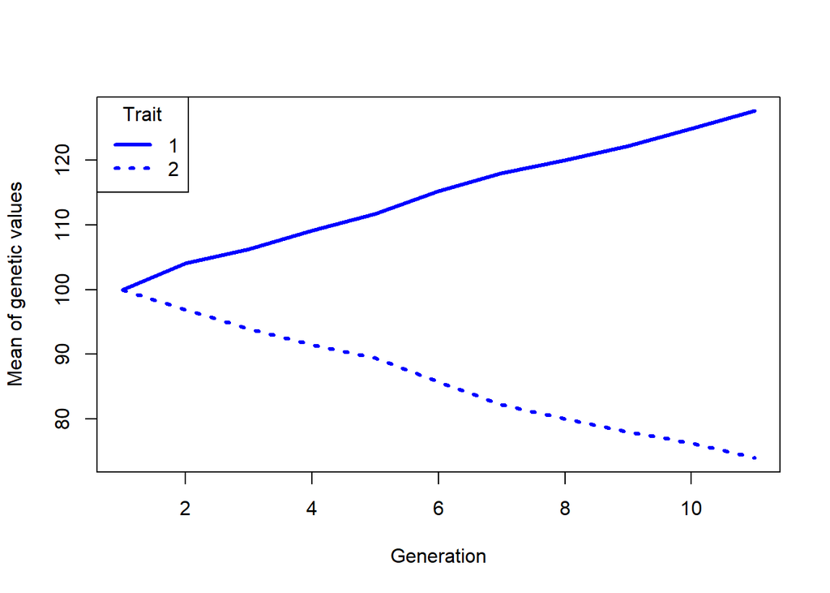

```r
# Store the results
nGenerations = 10 + 1 # +1 to store starting generation
meanG = vector("list", length = nGenerations)
varG = vector("list", length = nGenerations)

# Save the starting values
meanG[[1]] = meanG(basePop)
varG[[1]] = varG(basePop)

# First selection step
nSelected = 20
newPopSelected = selectInd(pop = basePop,
                           nInd = nSelected,
                           use = "pheno",
                           trait = 1)

# Selection over many generations
for (generation in 1:(nGenerations - 1)) {
  newPop = randCross(newPopSelected, nCrosses = nInd(basePop))
  newPop = setPheno(newPop, h2 = h2s)
  newPopSelected = selectInd(pop = newPop,
                             nInd = nSelected,
                             use = "pheno",
                             trait = 1)
  # Save summaries
  meanG[[1 + generation]] = meanG(newPop)
  varG[[1 + generation]] = varG(newPop)

}

# Plot results
meanGTrait1 = sapply(meanG, function(x) x[1])
meanGTrait2 = sapply(meanG, function(x) x[2])
meanRanges = range(c(meanGTrait1, meanGTrait2))

varGTrait1 = sapply(varG, function(x) x[1, 1])
varGTrait2 = sapply(varG, function(x) x[2, 2])
varRanges = range(c(varGTrait1, varGTrait2))

# Plot mean of genetic values over time
plot(x = 1:nGenerations, y = meanGTrait1, type = "l", col = "blue", lwd = 3,
     xlab = "Generation", ylab = "Mean of genetic values", ylim = meanRanges)
lines(x = 1:nGenerations, y = meanGTrait2, type = "l", col = "blue", lty = 3, lwd = 3)
legend(x = "topleft", legend = c("1", "2"), title = "Trait",
       lwd = 3, lty = c(1, 3), col = c("blue", "blue"))
```

## 3. Genomic selection using multiple-trait information

In this practice, we will show how to implement Genomic prediction/Genomic selection models in a Multi-trait multienvironment framework.

### Dataset

**Phenotypic data**  
We generated BLUEs (best linear unbiased estimation) for each trait, and it can be loaded from *Phenotypes.csv*.

```r
# Loading the data
Phenotypes = read.csv("Phenotypes.csv")

# As factor
Phenotypes$Genotype = Phenotypes$Genotype %>% as.factor
Phenotypes$Env = Phenotypes$Env %>% as.factor
```

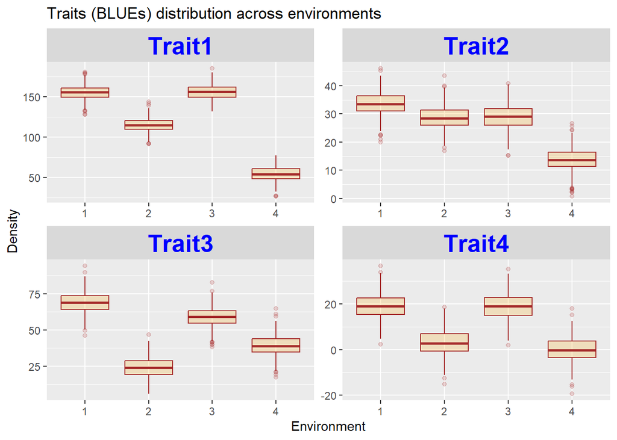

```r
Phenotypes[,c(1,3:6)] %>%
  pivot_longer(., cols = c('Trait1','Trait2','Trait3','Trait4')) %>%
ggplot(., aes(x = Env, y = value)) +
  geom_boxplot(color="brown", fill="orange", alpha=0.2) +
  theme(strip.text = element_text(face = "bold", size = 20, colour = 'blue'))+
  labs(x = 'Environment', title = "Traits (BLUEs) distribution across environments",y="Density")+
  facet_wrap(~name,scales = "free")
```

Using the trait 1 over four environments.

```r
# Organizing the phenotypic data

Y<- Phenotypes[,c(1,2,3)] %>%
  pivot_wider(., names_from = 'Env', values_from = 'Trait1')

# Scale the data
y = scale(Y[,-1])
```

**Genomic data**  
The genomic data (3000 SNP markers) was coded as 0,1,2 for aa,Aa,AA, respectively. The dataset for all 500 genotypes can be loaded from **Genotypes.csv**.

**Creating G Matrix**

Here, we will compose the additive relationship matrix (*G* matrix) following the propositions made by VanRaden (2008).

```
## Initial data:
##  Number of Individuals: 500
##  Number of Markers: 3000
##
## Missing data check:
##  Total SNPs: 3000
##   0 SNPs dropped due to missing data threshold of 1
##  Total of: 3000  SNPs
## MAF check:
##  No SNPs with MAF below 0
## Monomorphic check:
##  No monomorphic SNPs
## Summary check:
##  Initial:  3000 SNPs
##  Final:  3000  SNPs ( 0  SNPs removed)
##
## Completed! Time = 2.32  seconds
```

### Multitrait Model

**Statistical model**

The **GBLUP** model in a multitrait framework is given as follows:

$$y = 1u + Za + e$$

where $y$ is the matrix of BLUEs data for the target traits; $u$ represents the mean (fixed); $a$ is the matrix of genotype effects (assumed to be random), where $a \sim N(0,\sum_a\otimes G)$, $G$ is a matrix that describes the genomic similarities between pair of genotypes and $\sum_a$ represents the genetic covariance matrix; and $e$ is the residuals (random), where $e\sim N(0,\sum_{res}\otimes I)$, $\sum_{res}$ is the residual covariance matrix. The letter $Z$ refers to the incidence matrix for $a$. Here, we use the ‘Multitrait()’ function from BGLR package for fitting the model (Pérez-Rodrı́guez & Los Campos, 2022)

## 4. Model 1 - CV1

### **Multitrait model**

```r
# CROSS-VALIDATION CV1 (Predicting traits for new lines)

#--- 1. Setting the NA's
set.seed(12345)
yNA2 <- y
yNA2[sample(1:dim(Y)[1],100),] <- NA

#--- 2. Model
fm2 <- Multitrait(
         y = yNA2,
         ETA = list(A=list(K=G.Mat, model='RKHS', Cov = list(type = 'UN'))),
         resCov = list(type = 'DIAG'),
         nIter = 1200,
         burnIn = 120,
         thin = 5,
         verbose = FALSE)
```

```
## Checking variance co-variance matrix K  for linear term 1
```

```
## Ok
```

```
## Setting linear term 1
```

```
## MSx=1.49553739794528
```

```
## UNstructured covariance matrix
```

```
## df0 was set to 5
```

```
## S0 set to
```

```
##          1         2         3         4
## 1 3.545771 1.1278878 1.1837981 1.1138041
## 2 1.127888 3.3662059 1.0893164 0.9879803
## 3 1.183798 1.0893164 3.2704436 0.9928134
## 4 1.113804 0.9879803 0.9928134 3.1904703
```

```
## Initializing resCov
```

```
## Setting hyperparameters for DIAG R
```

```
## df0 set to  5 for all the traits
```

```
## S0 was set to
```

```
##        1        2        3        4
## 3.711983 3.524001 3.423749 3.340027
```

```
## Done
```

```r
#--- 3.  Extracting the estimated parameters
YHatInt2 <- fm2$ETAHat

#--- 4. Predictive correlation
  test2<-is.na(yNA2)
  tstB<-test2[,1] # Same position for all traits
  CORB.T1<-cor(YHatInt2[tstB,1],y[tstB,1])
  CORB.T2<-cor(YHatInt2[tstB,2],y[tstB,2])
  CORB.T3<-cor(YHatInt2[tstB,3],y[tstB,3])
  CORB.T4<-cor(YHatInt2[tstB,4],y[tstB,4])

#--- 4. Extracting estimates of variance parameters
(CORB.RES<-fm2$resCov$R) # residual covariance matrix
```

```
##          [,1]     [,2]      [,3]     [,4]
## [1,] 0.506008 0.000000 0.0000000 0.000000
## [2,] 0.000000 0.631697 0.0000000 0.000000
## [3,] 0.000000 0.000000 0.6420519 0.000000
## [4,] 0.000000 0.000000 0.0000000 0.604116
```

```r
(CORB.u<-fm2$ETA[[1]]$Cov$Omega) # genetic covariance matrix UE
```

```
##           1         2         3         4
## 1 0.4590653 0.2588641 0.2559555 0.2552953
## 2 0.2588641 0.3350281 0.2118696 0.2048813
## 3 0.2559555 0.2118696 0.3066488 0.2057984
## 4 0.2552953 0.2048813 0.2057984 0.3014032
```

```r
#--- 5. Trait correlation
cov2cor(CORB.u)
```

```
##           1         2         3         4
## 1 1.0000000 0.6600759 0.6821918 0.6863280
## 2 0.6600759 1.0000000 0.6610090 0.6447445
## 3 0.6821918 0.6610090 1.0000000 0.6769358
## 4 0.6863280 0.6447445 0.6769358 1.0000000
```

### **Single trait model**

```r
  #--- 1. Run single trait
  yB1NA <- yNA2[,1] #Trait 1
  yB2NA <- yNA2[,2] #Trait 2
  yB3NA <- yNA2[,3] #Trait 3
  yB4NA <- yNA2[,4] #Trait 4

  #--- 2. Model
  ETA2 <- list(a = list(K=G.Mat,model='RKHS'))
  fmB1 <- BGLR(yB1NA,ETA=ETA2,nIter=1200,burnIn=120,verbose=FALSE)
  fmB2 <- BGLR(yB2NA,ETA=ETA2,nIter=1200,burnIn=120,verbose=FALSE)
  fmB3 <- BGLR(yB3NA,ETA=ETA2,nIter=1200,burnIn=120,verbose=FALSE)
  fmB4 <- BGLR(yB4NA,ETA=ETA2,nIter=1200,burnIn=120,verbose=FALSE)

  #--- 3. Correlations
  CORB.ST1 <- cor(fmB1$yHat[tstB],y[tstB,1])
  CORB.ST2 <- cor(fmB2$yHat[tstB],y[tstB,2])
  CORB.ST3 <- cor(fmB3$yHat[tstB],y[tstB,3])
  CORB.ST4 <- cor(fmB4$yHat[tstB],y[tstB,4])
```

### **Correlation for the models (MT and ST)**

```r
#--- 1. Correlation output from both models
CorCV1 <- matrix(NA,nrow=4,ncol=2)
colnames(CorCV1) <- c('MT','ST')

  # MTM
  CorCV1[1,1] <- CORB.T1
  CorCV1[2,1] <- CORB.T2
  CorCV1[3,1] <- CORB.T3
  CorCV1[4,1] <- CORB.T4

  # STM
  CorCV1[1,2] <- CORB.ST1
  CorCV1[2,2] <- CORB.ST2
  CorCV1[3,2] <- CORB.ST3
  CorCV1[4,2] <- CORB.ST4

#--- 2. Comparison table

CorCV1
```

```
##             MT        ST
## [1,] 0.4790521 0.4018156
## [2,] 0.3719704 0.3362224
## [3,] 0.4133658 0.3524806
## [4,] 0.4197146 0.3407975
```

## 5. Model 2 - CV2

### **Multi trait model**

```r
## CROSS-VALIDATION CV2 (Partial Information via Associated Traits)

#--- 1. Set to NA the
set.seed(524521)
yNA <-y
yNA[sample(1:dim(Y)[1],100),1] <- NA
yNA[sample(1:dim(Y)[1],100),2] <- NA
yNA[sample(1:dim(Y)[1],100),3] <- NA
yNA[sample(1:dim(Y)[1],100),4] <- NA


#--- 2. Model
fm <- Multitrait(y = yNA,
                 ETA = list(A=list(K = G.Mat, model='RKHS', Cov = list(type = 'UN'))),
                 nIter = 1200,
                 burnIn = 120,
                 thin = 5,
                 verbose = FALSE)
```

```
## Checking variance co-variance matrix K  for linear term 1
```

```
## Ok
```

```
## Setting linear term 1
```

```
## MSx=1.49553739794528
```

```
## UNstructured covariance matrix
```

```
## df0 was set to 5
```

```
## S0 set to
```

```
##          1         2        3         4
## 1 3.357451 1.1475108 1.230007 1.2813106
## 2 1.147511 3.5389379 1.358102 0.9823556
## 3 1.230007 1.3581023 3.507723 1.2229457
## 4 1.281311 0.9823556 1.222946 3.4048273
```

```
## Initializing resCov
```

```
## Setting hyperparameters for UNstructured R
```

```
## S0 was set to
```

```
##          1        2        3        4
## 1 5.021194 1.716145 1.839521 1.916248
## 2 1.716145 5.292614 2.031093 1.469150
## 3 1.839521 2.031093 5.245931 1.828961
## 4 1.916248 1.469150 1.828961 5.092047
```

```
## Done
```

```r
#--- 3. Extracting the estimated parameters
YHatInt <- fm$ETAHat

#--- 4. Predictive correlation
test<-is.na(yNA)
tst1<-test[,1];tst2<-test[,2]<-tst3<-test[,3];tst4<-test[,4]
COR.T1<-cor(YHatInt[tst1,1],y[tst1,1])
COR.T2<-cor(YHatInt[tst2,2],y[tst2,2])
COR.T3<-cor(YHatInt[tst3,3],y[tst3,3])
COR.T4<-cor(YHatInt[tst4,4],y[tst4,4])

#--- 5. Extracting estimates of variance parameters
(COR.RES<-fm$resCov$R) # residual covariance matrix
```

```
##            1          2         3          4
## 1 0.53942397 0.08142737 0.1345714 0.07613355
## 2 0.08142737 0.74555259 0.2194581 0.06983051
## 3 0.13457140 0.21945809 0.7647425 0.12847156
## 4 0.07613355 0.06983051 0.1284716 0.67923635
```

```r
(COR.u<-fm$ETA[[1]]$Cov$Omega) # genetic covariance matrix UE
```

```
##           1         2         3         4
## 1 0.3694649 0.1542590 0.1543947 0.2009270
## 2 0.1542590 0.2499385 0.1314739 0.1302072
## 3 0.1543947 0.1314739 0.2333951 0.1516298
## 4 0.2009270 0.1302072 0.1516298 0.2830937
```

```r
#--- 6. Trait correlation
cov2cor(CORB.u)
```

```
##           1         2         3         4
## 1 1.0000000 0.6600759 0.6821918 0.6863280
## 2 0.6600759 1.0000000 0.6610090 0.6447445
## 3 0.6821918 0.6610090 1.0000000 0.6769358
## 4 0.6863280 0.6447445 0.6769358 1.0000000
```

### **Single-trait model**

```r
#--- 1. Run single trait model
  y1NA <- yNA[,1] #Trait 1
  y2NA <- yNA[,2] #Trait 2
  y3NA <- yNA[,3] #Trait 3
  y4NA <- yNA[,4] #Trait 4

#--- 2. ETA and model for each trait
  ETA <- list(A=list(K=G.Mat, model='RKHS'))
  fm1 <- BGLR(y1NA,ETA=ETA,nIter=1200,burnIn=120,verbose=FALSE)
  fm2 <- BGLR(y2NA,ETA=ETA,nIter=1200,burnIn=120,verbose=FALSE)
  fm3 <- BGLR(y3NA,ETA=ETA,nIter=1200,burnIn=120,verbose=FALSE)
  fm4 <- BGLR(y4NA,ETA=ETA,nIter=1200,burnIn=120,verbose=FALSE)

#--- 3. Correlation for single trait
  COR.ST1 <- cor(fm1$yHat[tst1],y[tst1,1])
  COR.ST2 <- cor(fm2$yHat[tst2],y[tst2,2])
  COR.ST3 <- cor(fm3$yHat[tst3],y[tst3,3])
  COR.ST4 <- cor(fm4$yHat[tst4],y[tst4,4])
```

### **Correlation for the models (MT and ST)**

```r
#--- 1. Correlation output from both models
CorCV2 <- matrix(NA,nrow=4,ncol=2)
colnames(CorCV2) <- c('MT','ST')

  # MTM
  CorCV2[1,1] <- COR.T1
  CorCV2[2,1] <- COR.T2
  CorCV2[3,1] <- COR.T3
  CorCV2[4,1] <- COR.T4

  # STM
  CorCV2[1,2] <- COR.ST1
  CorCV2[2,2] <- COR.ST2
  CorCV2[3,2] <- COR.ST3
  CorCV2[4,2] <- COR.ST4

#--- 2. Comparison table

CorCV2
```

```
##             MT        ST
## [1,] 0.5177216 0.4072383
## [2,] 0.6541127 0.7067715
## [3,] 0.3581804 0.2814229
## [4,] 0.3133186 0.2541725
```

## References

Gaynor, R. C., Gorjanc, G., & Hickey, J. M. (2021). AlphaSimR: An r package for breeding program simulations. *G3*, *11*(2), jkaa017.

Pérez-Rodrı́guez, P., & Los Campos, G. de. (2022). Multitrait bayesian shrinkage and variable selection models with the BGLR-r package. *Genetics*, *222*(1), iyac112.

VanRaden, P. M. (2008). Efficient methods to compute genomic predictions. *Journal of Dairy Science*, *91*(11), 4414–4423.

[^1]: University of Florida, mresende@ufl.edu
[^2]: University of Florida, jhernandezjarqui@ufl.edu
[^3]: University of Florida, deamorimpeixotom@ufl.edu